# Pre-Process Saved (Do Not Run)

```python
data = pd.read_csv("Metro_Interstate_Traffic_Volume.csv")
data["date_time"] = data["date_time"].apply(lambda x: datetime.strptime(x,"%Y-%m-%d %H:%M:%S"))
data['date'] = data["date_time"].apply(lambda x: x.date())
data['year'] = data["date"].apply(lambda x: x.year)
data['month'] = data['date'].apply(lambda x: x.month)
data['month_day'] = data["date"].apply(lambda x: x.day)
data['week_day'] = data["date"].apply(lambda x: x.weekday())
data['hour'] = data["date_time"].apply(lambda x: x.hour)
data.drop(np.asarray(data[data['temp'] == 0.0].index), inplace = True)
# 2014-1-31 has missing columns in between 03:00 - 08:00 so I ignored that part.
for index,j in data.iterrows():
    if(j['holiday'] != 'None'and data.at[index+2,'holiday'] == "None" ):
        for x in range(24):
            data.at[index + x,'holiday'] = j['holiday']

for index,j in data.iterrows():
    if(j['holiday'] == 'None'):
        data.at[index,'holiday_or_not'] = False
    else:
        data.at[index,'holiday_or_not'] = True

unqiue_weather = np.asarray(data['weather_main'].unique())
main_dict = dict([(y,x+1) for x,y in enumerate(sorted(set(unqiue_weather)))])

unqiue_descript = np.asarray(data['weather_description'].unique())
descript_dict = dict([(y,x+1) for x,y in enumerate(sorted(set(unqiue_descript)))])

unqiue_holidays = np.asarray(data['holiday'].unique())
holiday_dict = dict([(y,x+1) for x,y in enumerate(sorted(set(unqiue_holidays)))])

for index, j in data.iterrows():
    data.at[index,'weather_main_int'] = main_dict[j['weather_main']]
    data.at[index,'weather_description_int'] = descript_dict[j['weather_description']]
    data.at[index,'holiday_int'] = holiday_dict[j['holiday']]

data['weather_main_int'] = data['weather_main_int'].astype('int64')
data['weather_description_int'] = data['weather_description_int'].astype('int64')
data['holiday_int'] = data['holiday_int'].astype('int')
for index, i in data.iterrows():
    day = i.week_day
    data.at[index, 'normalized']= data.at[index,'traffic_volume'] - weekly_grouped.mean()['traffic_volume'][day]

train = data[data['year'] != 2018]
test =  data[data['year'] == 2018]
```

```python
data.to_csv('data_modified.csv')
train = data[data['year'] != 2018]
test =  data[data['year'] == 2018]
train.to_csv('train.csv')
test.to_csv('test.csv')
```

# Imports

```python
import pandas as pd
from datetime import datetime
import seaborn as sns
import matplotlib.pyplot as plt
import plotly.graph_objs as go
import plotly.express as px
```

```python
test = pd.read_csv('test.csv')
test.drop('Unnamed: 0', axis = 1 ,inplace = True)
data = pd.read_csv('data_modified.csv')
data.drop('Unnamed: 0', axis = 1 ,inplace = True)
train = pd.read_csv('train.csv')
train.drop('Unnamed: 0', axis = 1 ,inplace = True)
```

```python
daily_grouped = data.groupby('date')
monthly_grouped = data.groupby('month')
monthly_day_grouped = data.groupby('month_day')
weekly_grouped = data.groupby('week_day')
holiday_grouped = data.groupby('holiday')
clouds_all_grouped = data.groupby('clouds_all')
```

# Exploratory

```python
fig = go.Figure([go.Scatter(x=daily_grouped.sum().index, y=daily_grouped.sum()['traffic_volume'])])
fig.show()
```

[interactive chart not shown]

There is obviously missing data in 2015.

```python
fig = go.Figure([go.Scatter(x=weekly_grouped.mean().index,
                            y=weekly_grouped.mean()['traffic_volume'])])

fig.update_layout(title = "Weekly Mean")
fig.show()
```

[interactive chart not shown]

As plot shows the weekdays have much more traffic volume compared to weekends. Therefore to normalize this effect from now on I will extract the means from the original data and go with it.

```python
fig = go.Figure([go.Scatter(x=holiday_grouped.mean().index,
                            y=holiday_grouped.mean()['normalized'])])

fig.update_layout(title = "Holiday Mean")
fig.show()
```

[interactive chart not shown]

There is obviously different traffic patterns for each holiday. Also, it is clear that on the most of the holidays the traffic volume is below average.

```python
from plotly.subplots import make_subplots
fig = make_subplots(rows=1, cols=2)

fig.add_trace(
    go.Scatter(x=data.groupby('weather_main').mean().index,
                            y=data.groupby('weather_main').mean()['traffic_volume'],name = 'Traffic Volume')

)

fig.add_trace(
    go.Scatter(x=data.groupby('weather_main').mean().index,
                            y=data.groupby('weather_main').mean()['normalized'], name = 'Weekly Normalized Traffic Volume'),
    row =1, col = 2
)

fig.update_layout(height=600, width=1000, title_text="Weather Main Effects",
                         )
fig.show()
```

[interactive chart not shown]

Since the x axis doesn't completely sorted in a way that 5 is worse/better than 4 and also due to different frequencies of the observations, there is no clear trend on the data but examining 4 year data indicates that there is correlation. First I plotted traffic volume but then I realized that weekday might be bias for weather so I decided to plot normalized data and it gave almost the same pattern. That is there might be information embedded in the weather main data.

```python
from plotly.subplots import make_subplots
fig = make_subplots(rows=1, cols=2)

fig.add_trace(
    go.Scatter(x=data.groupby('weather_description').mean().index,
                            y=data.groupby('weather_description').mean()['traffic_volume'],name = 'Traffic Volume')

)

fig.add_trace(
    go.Scatter(x=data.groupby('weather_description').mean().index,
                            y=data.groupby('weather_description').mean()['normalized'], name = 'Weekly Normalized Traffic Volume'),
    row =1, col = 2
)

fig.update_layout(height=600, width=1000, title_text="Weather Description Effects",
                         )
fig.show()
```

[interactive chart not shown]

Above analysis is valid for weather main description too. However using these two columns as exogenous variables might cause bias since they both explains the same thing(ie weather) so I decided to use only weather main for the simplicity of the model.

```python
from plotly.subplots import make_subplots
fig = make_subplots(rows=1, cols=2)

fig.add_trace(
    go.Scatter(x=clouds_all_grouped.mean().index,
                            y=clouds_all_grouped.mean()['traffic_volume'],name = 'Traffic Volume')

)

fig.add_trace(
    go.Scatter(x=clouds_all_grouped.mean().index,
                            y=clouds_all_grouped.mean()['normalized'], name = 'Weekly Normalized Traffic Volume'),
    row =1, col = 2
)

fig.update_layout(height=600, width=1000, title_text="Clouds All Effects",
                         )
fig.show()
```

[interactive chart not shown]

Different than above columns, we would expect to see a trend on the clouds_all column since it is supplied as a 0-100 scale. Namely, 100 is more cloudy than 80. But obviously there is no correlation. So I will not use it.

```python
fig = go.Figure([go.Scatter(x=monthly_day_grouped.mean().index,
                            y=monthly_day_grouped.mean()['traffic_volume'])])
fig.update_layout(title = "Monthly Mean")
fig.show()
```

[interactive chart not shown]

Since the monthly mean data shows randomness and there is no implicit information embedded in the monthly day data (ie nobody cares if its the 4th or 6th of a month when using metro) I will not use this column.

```python
fig = go.Figure([go.Scatter(x=monthly_grouped.mean().index,
                            y=monthly_grouped.mean()['traffic_volume'])])
fig.update_layout(title = "Monthly Mean")
fig.show()
```

[interactive chart not shown]

When we consider the seasonality we see that during the summer,spring and fall there is high traffic volume except july which might be due to most of the people go to holiday etc. Namely, month is an indicator of traffic volume.

```python
len(data[data['snow_1h']==0]), len(data[data['snow_1h'] !=0])
```

```
(48131, 63)
```

As seen on the above numbers, there is high frequency of the snow_1h =0. Since most of the data has 0 value and the weather main column seems a good indicator of snowiness I decided not to use and snow_1h column.

```python
data['temp'].min(), data['temp'].max()
```

```
(243.39, 310.07)
```

```python
temp_discrt = np.digitize(data['temp'],np.arange(243.39,310.07,10))
data['disc_temp'] = temp_discrt
```

```python
fig = go.Figure([go.Scatter(x=data.groupby('disc_temp').mean().index,
                            y=data.groupby('disc_temp').mean()['traffic_volume'])])
fig.update_layout(title = "Temp Mean")
fig.show()
```

[interactive chart not shown]

The trend is obvious on the temperature data.

```python
data.columns
```

```
Index(['holiday', 'temp', 'rain_1h', 'snow_1h', 'clouds_all', 'weather_main',
       'weather_description', 'date_time', 'traffic_volume', 'date', 'year',
       'month', 'month_day', 'week_day', 'hour', 'holiday_or_not',
       'weather_main_int', 'weather_description_int', 'holiday_int',
       'normalized', 'disc_temp'],
      dtype='object')
```

# Forecast

```python
import pyflux
from statsmodels.tsa.seasonal import seasonal_decompose
import statsmodels.api as sm
from matplotlib import pyplot
from pmdarima.arima import auto_arima
```

```python
train.drop(['temp','snow_1h','holiday','clouds_all','weather_main','weather_description','year','month_day'
            ,'normalized'],inplace = True,axis =1 )
test.drop(['temp','snow_1h','holiday','clouds_all','weather_main','weather_description','year','month_day'
            ,'normalized'],inplace = True,axis =1 )
```

```python
weekly_decom = seasonal_decompose(train['traffic_volume'],model = "additive", period = 168)
train['seasonality']= weekly_decom_seaonal
train['normalized'] = train['traffic_volume'] - train['seasonality']
```

```python
weekly_decom_test = seasonal_decompose(test['traffic_volume'],model = "additive", period = 168)
test['seasonality']= weekly_decom_test.seasonal
test['normalized'] = test['traffic_volume'] - test['seasonality']
```

```python
weekly_decom_seaonal = pd.DataFrame(weekly_decom.seasonal)
weekly_decom_seaonal_plot = weekly_decom_seaonal.loc[0:168]
fig = go.Figure([go.Scatter(x = weekly_decom_seaonal_plot.index, y = weekly_decom_seaonal_plot['seasonal'])])
fig.update_layout(title = "Weekly Seasonality")
fig.show()
```

[interactive chart not shown]

```python
weekly_decom_trend = pd.DataFrame(weekly_decom.trend)
weekly_decom_trend = weekly_decom_trend.iloc[-252:-84]
fig = go.Figure([go.Scatter(x = weekly_decom_trend.index, y = weekly_decom_trend['trend'])])
fig.update_layout(title = "Weekly Trend")
fig.show()
```

[interactive chart not shown]

```python
# Weekly linear trend forecast
def trend_forecast(tablo):
    x, y = np.arange(168),tablo.traffic_volume#tablo.iloc[-168:]['traffic_volume']
    x = sm.add_constant(x)
    model = OLS(y,x)
    result_OLS = model.fit()
    #trend_forecast_weekly = [result_OLS.params.x1*(168+i) + result_OLS.params.const for i in range(24)]
    trend_forecast_daily = result_OLS.params.x1*(169)
    return trend_forecast_daily#,trend_forecast_weekly
```

```python
from statistics import mean
def weekly_trend(data):
    data = data[-168*4:]
    first_week = data[:168]
    second_week = data[168:168*2]
    third_week = data[168*2:168*3]
    fourth_week = data[168*3:168*4]
    m1,m2,m3,m4 = mean(first_week),mean(second_week),mean(third_week),mean(fourth_week)
    x, y = np.arange(4),[m1,m2,m3,m4]
    x = sm.add_constant(x)
    model = OLS(y,x)
    result_OLS = model.fit()
    trend_forecast = result_OLS.params[1]*5 + result_OLS.params[0]
    return trend_forecast
```

```python
def error_forecast(tablo):
    series = tablo["traffic_volume"]
    model = auto_arima(series)
    model.fit(series)
    return model
```

## DynamicRegression

```python
dynamic_reg_model1 = pyflux.DynReg('traffic_volume ~ week_day + hour + weather_main_int + month',
                                   data = train[['traffic_volume','week_day','hour',"weather_main_int","month"]])
dynamic_reg_model1.fit()
model1_predictions = dynamic_reg_model1.predict(len(test),oos_data = test[['traffic_volume','week_day','hour',
                                                                       "weather_main_int","month"]])
```

```python
dynamic_reg_model2 = pyflux.DynReg('traffic_volume ~ week_day + hour + weather_main_int + month + holiday_int + holiday_or_not',
                                   data = train[-20000:][['traffic_volume','week_day','hour',"weather_main_int","month",
                                                "holiday_int","holiday_or_not"]])
dynamic_reg_model1.fit()
model2_predictions = dynamic_reg_model1.predict(len(test),oos_data =
                                                test[['traffic_volume','week_day','hour',"weather_main_int",
                                                      "month","holiday_int","holiday_or_not"]])
```

## AutoRegressive Model

The second regressive model is autoregressive model where the data is only thought to be related to previous observations. The fitted model from trained data returned AR model order of 54. So I proceeded to forecast test data with the order and coefficients learned from trained data.

```python
from statsmodels.tsa.ar_model import AR
from statsmodels.regression.linear_model import OLS
```

```python
AR_model = AR(train['traffic_volume'])
AR_model_fitted = AR_model.fit()
AR_model_predictions_2 = [sum(AR_model_fitted.params[i+1]*test[i+1:i+2]['traffic_volume'] for i in range(54))
                          +AR_model_fitted.params[0]]
```

```python
AR_model_predictions = []
for j in range(len(test)):
    x =AR_model_fitted.params[0]
    for i in range(54):
        x += (AR_model_fitted.params[i+1]*data.loc[i+j+len(train)].traffic_volume)
    AR_model_predictions.append(x)
```

## Multivariable Linear Regression

The third regressive model I developed is multi-variable linear regression model. I gave the same exogenous variables to model as in dynamic regression model

```python
from sklearn import linear_model
```

```python
X = train[['week_day','hour','holiday_or_not','holiday_int','weather_main_int','month']]
Y = train['traffic_volume']
regr = linear_model.LinearRegression()
regr.fit(X, Y)
ml_predict = regr.predict(test[['week_day','hour','holiday_or_not','holiday_int','weather_main_int','month']])
```

## ARIMA without exo

```python
from statsmodels.tsa.arima_model import ARIMA
model = error_forecast(train)
order = model.order
error_forecast = ARIMA(test['normalized'],order).fit().predict()
trend_forecasts = [weekly_trend(data[:40245+i].normalized) for i in range(len(test))]
```

```python
ARIMA_1_predictions = test['seasonality'] + trend_forecasts + error_forecast
```

## ARIMA with exo

```python
model = auto_arima(train['normalized'],
                   exogenous = train[['week_day','hour','holiday_int','weather_main_int','month']])
model.fit(train['normalized'],
                   exogenous = train[['week_day','hour','holiday_int','weather_main_int','month']])
error_forecast2 = model.predict(len(test),exogenous = test[['week_day','hour',
                                                            'holiday_int','weather_main_int','month']])

ARIMA_2_predictions = test['seasonality'] + trend_forecasts + error_forecast2
ARIMA_2_predictions.to_csv('ARIMA_2_predictions.csv')
```

# Final

```python
model1_pred = pd.read_csv('model1_pred.csv')
model2_pred = pd.read_csv('model2_pred.csv')
ml_pred = pd.read_csv('ml_predict.csv')
AR_pred = pd.read_csv('AR_model_predictions.csv')
ARIMA_pred = pd.read_csv('ARIMA_1_predictions.csv')
ARIMA_exo_pred = pd.read_csv('ARIMA_2_predictions.csv')
```

```python
ssss = {"model1":model1_pred.traffic_volume,'model2':model2_pred.traffic_volume
       ,'ml':ml_pred['0'],'AR':AR_pred['0'],'ARIMA':ARIMA_pred['0'],'ARIMA_exo':ARIMA_exo_pred['seasonality']}
```

```python
final_preds = pd.DataFrame(ssss)
```

```python
final_preds['traffic_volume']=test['traffic_volume']
```

```python
final_preds['error_model1'] = abs(final_preds['model1']-final_preds['traffic_volume'])
final_preds['error_model2'] = abs(final_preds['model2']-final_preds['traffic_volume'])
final_preds['error_ml'] = abs(final_preds['ml']-final_preds['traffic_volume'])
final_preds['error_AR'] = abs(final_preds['AR']-final_preds['traffic_volume'])
final_preds['error_ARIMA'] = abs(final_preds['ARIMA']-final_preds['traffic_volume'])
final_preds['error_ARIMA_exo'] = abs(final_preds['ARIMA_exo']-final_preds['traffic_volume'])
```

```python
final_preds['average'] = (final_preds['model1'] + final_preds['model2'] + final_preds['ml']+ final_preds['AR'] + final_preds['ARIMA']+final_preds['ARIMA_exo'])/6
```

```python
final_preds['error_average'] = abs(final_preds['average']-final_preds['traffic_volume'])
```

```python
[mean(final_preds['error_model1'].dropna()),mean(final_preds['error_model2'].dropna()),
 mean(final_preds['error_ml'].dropna()),mean(final_preds['error_AR'].dropna()),
 mean(final_preds['error_ARIMA'].dropna()),mean(final_preds['error_ARIMA_exo'].dropna()),
 mean(final_preds['error_average'].dropna())]
```

```
[2215.149081657846,
 2215.149081657846,
 1602.7900550006611,
 383.1225511647074,
 553.970847470612,
 1675.7165725252444,
 1259.9998436953033]
```

# Analysis

It seems that the best results is achieved from simple AR model. However, I suspect that I've failed of indexing in ARIMA. Because I made forecasting manually, probably I've failed when appending forecast to corresponding day time. When I check plots of original data and ARIMA predictions the plots are seems very similar so its a good sign of there is drifting error in the data. Also ARIMA_exo might be overfitting the data, because I've already normalized the data with weekday and hour, it seems problematic to use weekday and hour. Multivariable Linear regression seems to be can't catch the seasonality in the data very good and dynamic regression model doesn't make sense at all.

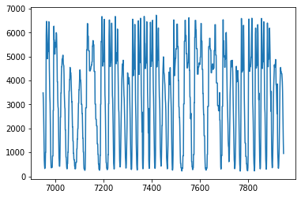

```python
final_preds['traffic_volume'][-1000:].plot()
```

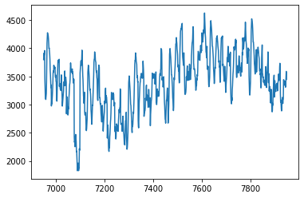

```python
final_preds['ARIMA_exo'][-1000:].plot()
```

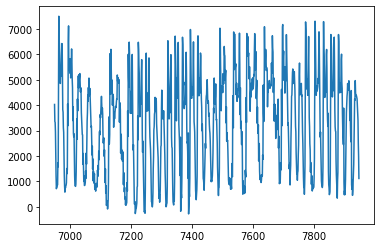

```python
final_preds['ARIMA'][-1000:].plot()
```

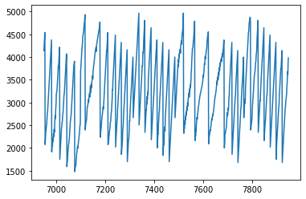

```python
final_preds['ml'][-1000:].plot()
```

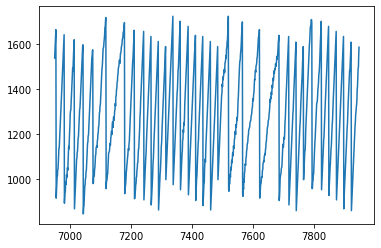

```python
final_preds['model1'][-1000:].plot()
```

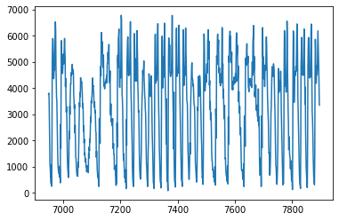

```python
final_preds['AR'][-1000:].plot()
```